# HDZ na društvenim mrežama

Lux

03 05 2021

### Općenito

Podatci se odnose na objave na Twitteru i Facebook-u u razdoblju od 10/04/2021 do 05/05/2021 i uključuju 52.300 objava.  
**Koliko često korisnici digitalnih platformi Facebook i Twitter spominju Hrvatsku demokratsku zajednicu u svojim objavama na Facebooku i Twitteru**  
Broj profila koji su objavili nešto o HDZ-u: 1524.  
Broj aktivnosti: 52293.

Broj objava po platformi

| source | BrojObjava |
| --- | --- |
| Facebook | 50742 |
| Twitter | 1551 |

Broj objava po platformi i vrsti objave

| type | source | BrojObjava |
| --- | --- | --- |
| comment | Facebook | 45767 |
| UNKNOWN | Facebook | 2783 |
| album | Facebook | 1123 |
| photo | Facebook | 1008 |
| reply | Twitter | 638 |
| status | Twitter | 484 |
| retweet | Twitter | 341 |
| quote | Twitter | 88 |
| status | Facebook | 57 |
| video | Facebook | 4 |

Broj objava na Twitteru prema autorima

| author | BrojObjavaTwitter |
| --- | --- |
| Visoki sud časti HDZ-a F⬛️⬛️Y⬛️ | 116 |
| Darko | 43 |
| Marinko Kordić | 37 |
| Dnevno.hr | 32 |
| dr.Karosh | 32 |
| Neovisni analitičar🇭🇷 | 30 |
| Romi | 23 |
| Sanja Adjivon | 22 |
| Slaven ptsp zds dz itd… | 22 |
| Skeptični Toma | 20 |
| Visitor | 19 |
| Mario Lakuš | 18 |
| Cro Cop | 17 |
| Gordan Vrelo Bosne Duhaček | 17 |
| rećina | 16 |
| Ninoslav Šafarić | 15 |
| HDZ | 14 |
| Marcos Ruppert | 14 |
| Ilija Ćaitos Teklić | 13 |
| ZoranB1708 | 13 |
| Vipera | 12 |
| Dalmatinski portal | 11 |
| Otvoreno.hr | 11 |
| siniša mijakić | 11 |
| 𝘓𝘶𝘤𝘬𝘺 𝘓𝘶𝘬𝘦 🇪🇺 | 10 |
| HRT vijesti | 10 |
| asja bakić | 9 |
| Bećirović Vanja | 9 |
| Damir Japelj, dosta mi je kiča više! | 9 |
| Internationalism | 9 |

[output cut: 441 more lines]

Broj objava na FB prema autorima

| author | BrojObjavaFB |
| --- | --- |
| NA | 45483 |
| Narod.hr | 50 |
| HDZ-Krnjak | 45 |
| Dnevno.hr | 44 |
| HDZ - Lokalni Izbori | 43 |
| DalmacijaDanas | 41 |
| HDZ Varaždinske županije | 37 |
| Mladež HDZ-a Vrbanja | 36 |
| Zadarski.hr | 35 |
| Index Vijesti | 31 |
| Index.hr | 31 |
| Direktno.hr | 30 |
| 7dnevno.hr | 29 |
| HDZ Karlovačke županije | 29 |
| ŽO HDZ VSŽ | 29 |
| Otvoreno.hr | 28 |
| HDZ - Hrvatska demokratska zajednica | 27 |
| PO NZI HDZ -Katarina Zrinski | 27 |
| Dalmatinski portal | 26 |
| HDZ KArlovac | 25 |
| Hdz Ravna Gora | 25 |
| HDZ Zagreb | 25 |
| Hrvatskadanas | 25 |
| Mladež HDZ Vinkovci | 25 |
| OGČ HDZ Peščenica - Žitnjak | 25 |
| HDZ Brdovec | 24 |
| HDZ Jelenje | 24 |
| HDZ Primorsko-goranske županije | 24 |
| HDZ Vrgorac | 24 |
| Mladež HDZ-a Virovitičko-podravske županije | 24 |

[output cut: 1046 more lines]

Broj pratitelja na Twitteru po profilu

| author | audience | source |
| --- | --- | --- |
| DNEVNIK.hr | 231888 | Twitter |
| 24sata | 184717 | Twitter |
| 24sata | 184715 | Twitter |
| 24sata | 184641 | Twitter |
| Večernji list | 168361 | Twitter |
| TV N1 Beograd | 154434 | Twitter |
| Europe Elects | 115092 | Twitter |
| Europe Elects | 114389 | Twitter |
| Klix.ba | 103079 | Twitter |
| Radio101 | 94330 | Twitter |
| Radio101 | 94310 | Twitter |
| N1english | 48993 | Twitter |
| Andrej Plenković | 47265 | Twitter |
| HRT vijesti | 31330 | Twitter |
| HRT vijesti | 31270 | Twitter |
| RadioSlobodnaEvropa | 27558 | Twitter |
| TV N1 Zagreb | 25366 | Twitter |
| TV N1 Zagreb | 25257 | Twitter |
| Bojan Glavasevic | 15066 | Twitter |
| HDZ | 12552 | Twitter |
| HDZ | 12548 | Twitter |
| SDPHrvatske | 12467 | Twitter |
| SDPHrvatske | 12466 | Twitter |
| Telegram | 12369 | Twitter |
| Helena Puljiz | 11114 | Twitter |
| Helena Puljiz | 11113 | Twitter |
| Marija Lugarić | 10544 | Twitter |
| Dejan Jovic | 10304 | Twitter |
| Marko Rakar | 9819 | Twitter |
| Domagoj Margetic | 9642 | Twitter |

[output cut: 548 more lines]

Broj pratitelja na FB po profilu

| author | audience | source |
| --- | --- | --- |
| 24sata | 1420285 | Facebook |
| Index.hr | 998386 | Facebook |
| Index.hr | 998380 | Facebook |
| Index.hr | 997972 | Facebook |
| Jutarnji | 764965 | Facebook |
| Jutarnji | 764829 | Facebook |
| DNEVNIK.hr | 757542 | Facebook |
| DNEVNIK.hr | 757300 | Facebook |
| Net.hr | 660998 | Facebook |
| Net.hr | 660773 | Facebook |
| Večernji list | 581660 | Facebook |
| Večernji list | 580947 | Facebook |
| Al Jazeera Balkans | 552209 | Facebook |
| Tportal.hr | 350354 | Facebook |
| Tportal.hr | 350227 | Facebook |
| Zoran Šprajc | 332788 | Facebook |
| Zoran Šprajc | 332224 | Facebook |
| Telegram.hr | 294857 | Facebook |
| Telegram.hr | 294740 | Facebook |
| Radio Banovina | 245051 | Facebook |
| Index Vijesti | 209325 | Facebook |
| Index Vijesti | 209316 | Facebook |
| Slobodna Dalmacija | 202390 | Facebook |
| Slobodna Dalmacija | 202144 | Facebook |
| Živi zid | 178053 | Facebook |
| Dnevno.hr | 171793 | Facebook |
| Dnevno.hr | 170716 | Facebook |
| HRT Vijesti | 159307 | Facebook |
| 24sata Politiko | 143589 | Facebook |
| 24sata Politiko | 143586 | Facebook |

[output cut: 1383 more lines]

Broj objava prema vrsti i profilu na FB

| author | type | n |
| --- | --- | --- |
| Narod.hr | UNKNOWN | 50 |
| Dnevno.hr | UNKNOWN | 44 |
| DalmacijaDanas | UNKNOWN | 41 |
| Zadarski.hr | UNKNOWN | 35 |
| HDZ-Krnjak | album | 33 |
| Index Vijesti | UNKNOWN | 31 |
| Index.hr | UNKNOWN | 31 |
| Direktno.hr | UNKNOWN | 30 |
| 7dnevno.hr | UNKNOWN | 29 |
| Otvoreno.hr | UNKNOWN | 28 |
| Dalmatinski portal | UNKNOWN | 26 |
| HDZ - Lokalni Izbori | album | 26 |
| Hrvatskadanas | UNKNOWN | 25 |
| Mladež HDZ-a Vrbanja | UNKNOWN | 25 |
| Denis Latin | UNKNOWN | 22 |
| HDZ Primorsko-goranske županije | UNKNOWN | 22 |
| Telegram.hr | UNKNOWN | 22 |
| Dubrovnik INsider | UNKNOWN | 21 |
| HDZ - Hrvatska demokratska zajednica | album | 21 |
| HDZ Karlovačke županije | album | 21 |
| HDZ Ličko-senjske Županije | UNKNOWN | 21 |
| Lika portal | UNKNOWN | 21 |
| Mladež HDZ-a Virovitičko-podravske županije | UNKNOWN | 20 |
| HDZ Brdovec | photo | 19 |
| OGČ HDZ Peščenica - Žitnjak | album | 19 |
| Priznajem.hr | UNKNOWN | 19 |
| ŽO HDZ VSŽ | UNKNOWN | 19 |
| HDZ Varaždinske županije | album | 18 |
| HDZ Vrgorac | photo | 18 |
| Portal Aktualno Hr | UNKNOWN | 18 |

[output cut: 1504 more lines]

Broj objava prema vrsti i profilu na Twitteru

| author | type | n |
| --- | --- | --- |
| Visoki sud časti HDZ-a F⬛️⬛️Y⬛️ | reply | 72 |
| Darko | reply | 43 |
| Dnevno.hr | status | 32 |
| Visoki sud časti HDZ-a F⬛️⬛️Y⬛️ | status | 32 |
| Marinko Kordić | retweet | 28 |
| Romi | reply | 21 |
| dr.Karosh | reply | 18 |
| Mario Lakuš | reply | 18 |
| Slaven ptsp zds dz itd… | reply | 18 |
| Visitor | reply | 16 |
| Neovisni analitičar🇭🇷 | status | 15 |
| Marcos Ruppert | retweet | 14 |
| Cro Cop | retweet | 12 |
| Vipera | reply | 12 |
| Dalmatinski portal | status | 11 |
| Otvoreno.hr | status | 11 |
| dr.Karosh | status | 10 |
| HRT vijesti | status | 10 |
| rećina | retweet | 10 |
| Visoki sud časti HDZ-a F⬛️⬛️Y⬛️ | quote | 10 |
| Damir Japelj, dosta mi je kiča više! | reply | 9 |
| Loba Do Mar | retweet | 9 |
| Miletich-Barkovich | retweet | 9 |
| Ninoslav Šafarić | reply | 9 |
| Skeptični Toma | status | 9 |
| Bećirović Vanja | retweet | 8 |
| Gordan Vrelo Bosne Duhaček | status | 8 |
| Kuki | reply | 8 |
| ŽO HDZ VSŽ | status | 8 |
| Cynical0bserver 🇭🇷🇺🇸🇧🇦 | retweet | 7 |

[output cut: 600 more lines]

Broj like-ova prema autoru i platformi

| author | source | Likes |
| --- | --- | --- |
| NA | Facebook | 71587 |
| HDZ - Hrvatska demokratska zajednica | Facebook | 6883 |
| Velimir Bujanec | Facebook | 4854 |
| HDZ Zagreb | Facebook | 2105 |
| HDZ Vrgorac | Facebook | 2070 |
| Karolina Vidović Krišto | Facebook | 1845 |
| Index.hr | Facebook | 1762 |
| Domovinski pokret | Facebook | 1714 |
| HDZ KArlovac | Facebook | 1580 |
| Narod.hr | Facebook | 1426 |
| DalmacijaDanas | Facebook | 1392 |
| HDZ Karlovačke županije | Facebook | 1368 |
| ŽO HDZ VSŽ | Facebook | 1288 |
| Telegram.hr | Facebook | 1240 |
| Hrvatskadanas | Facebook | 1195 |
| HDZ Osječko-baranjske županije | Facebook | 1159 |
| Ivan Anušić | Facebook | 1103 |
| Nikola Grmoja | Facebook | 1004 |
| Želim biti Milan Bandić gradonačelnik svemira | Facebook | 1002 |
| Zoran Šprajc | Facebook | 976 |
| Hdz Sisak | Facebook | 918 |
| Mladež HDZ | Facebook | 789 |
| Marko Marušić | Facebook | 711 |
| Ivan Vilibor Sinčić | Facebook | 708 |
| Indirektno | Facebook | 699 |
| Dalmatinski portal | Facebook | 688 |
| Tomislav Karamarko | Facebook | 663 |
| Hdz Ravna Gora | Facebook | 659 |
| Slobodna Dalmacija | Facebook | 644 |
| HDZ Osijek | Facebook | 639 |

[output cut: 1517 more lines]

**Kolika je raspršenost pojedinaca (profila) koji iznose svoja mišljenja i stavove o Hrvatskoj demokratskoj zajednici (objavljuju li uvijek isti profili objave o HDZ-u)**

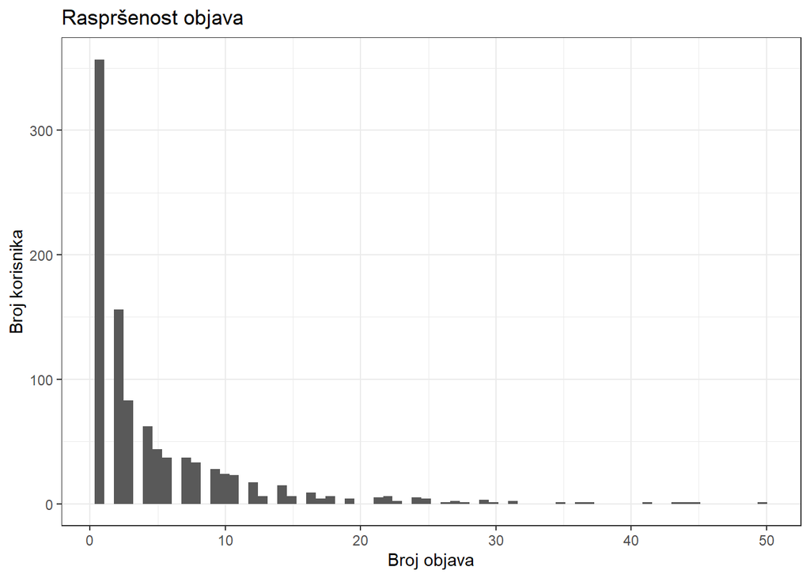

| author | BrojObjava |
| --- | --- |
| Narod.hr | 50 |
| HDZ-Krnjak | 45 |
| Dnevno.hr | 44 |
| HDZ - Lokalni Izbori | 43 |
| DalmacijaDanas | 41 |
| HDZ Varaždinske županije | 37 |
| Mladež HDZ-a Vrbanja | 36 |
| Zadarski.hr | 35 |
| Index Vijesti | 31 |
| Index.hr | 31 |
| Direktno.hr | 30 |
| 7dnevno.hr | 29 |
| HDZ Karlovačke županije | 29 |
| ŽO HDZ VSŽ | 29 |
| Otvoreno.hr | 28 |
| HDZ - Hrvatska demokratska zajednica | 27 |
| PO NZI HDZ -Katarina Zrinski | 27 |
| Dalmatinski portal | 26 |
| HDZ Zagreb | 25 |
| Hrvatskadanas | 25 |
| Mladež HDZ Vinkovci | 25 |
| OGČ HDZ Peščenica - Žitnjak | 25 |

**Postoje li čvorišta iz kojih kreće u prosjeku relativno veći broj objava o Hrvatskoj demokratskoj zajednici te definirati doseg objava iz čvorišta**

Doseg objava iz čvorišta %

| author | Udio |
| --- | --- |
| Narod.hr | 1.01 |
| HDZ-Krnjak | 0.90 |
| Dnevno.hr | 0.88 |
| HDZ - Lokalni Izbori | 0.86 |
| DalmacijaDanas | 0.82 |
| HDZ Varaždinske županije | 0.74 |
| Mladež HDZ-a Vrbanja | 0.72 |
| Zadarski.hr | 0.70 |
| Index Vijesti | 0.62 |
| Index.hr | 0.62 |
| Direktno.hr | 0.60 |
| 7dnevno.hr | 0.58 |
| HDZ Karlovačke županije | 0.58 |
| ŽO HDZ VSŽ | 0.58 |
| Otvoreno.hr | 0.56 |
| HDZ - Hrvatska demokratska zajednica | 0.54 |
| PO NZI HDZ -Katarina Zrinski | 0.54 |
| Dalmatinski portal | 0.52 |
| HDZ Zagreb | 0.50 |
| Hrvatskadanas | 0.50 |
| Mladež HDZ Vinkovci | 0.50 |
| OGČ HDZ Peščenica - Žitnjak | 0.50 |
| HDZ Brdovec | 0.48 |
| HDZ KArlovac | 0.48 |
| HDZ Primorsko-goranske županije | 0.48 |
| HDZ Vrgorac | 0.48 |
| Mladež HDZ-a Virovitičko-podravske županije | 0.48 |
| HDZ Ličko-senjske Županije | 0.46 |
| HDZ Slunj | 0.46 |
| Denis Latin | 0.44 |

[output cut: 961 more lines]

Udio originalnog sadržaja na FB % od HDZ profila

| type | UdioOrig |
| --- | --- |
| album | 1.98 |
| UNKNOWN | 1.59 |
| photo | 1.49 |
| comment | 0.12 |
| status | 0.05 |

Udio originalnog sadržaja na FB % od ne HDZ profila

| type | UdioOrig |
| --- | --- |
| UNKNOWN | 3.88 |
| photo | 0.49 |
| comment | 0.48 |
| album | 0.23 |
| status | 0.04 |
| video | 0.01 |

**Udio objava o Hrvatskoj demokratskoj zajednici koji su izvorni sadržaj i udio objava koji su nastali kao dijeljenje već postojećeg sadržaja (share i retweet)**

Ovaj dio se odnosi na ukupni sadržaj (pri tome se misli na orginalni i neorginalni):

Udio sadržaja na Twitteru %

| type | UdioOrig |
| --- | --- |
| reply | 41.1 |
| status | 31.2 |
| retweet | 22.0 |
| quote | 5.7 |

Udio originalnog sadržaja na FB :

Udio sadržaja na FB %

| type | UdioOrig |
| --- | --- |
| comment | 90.20 |
| UNKNOWN | 5.48 |
| album | 2.21 |
| photo | 1.99 |
| status | 0.11 |
| video | 0.01 |

| author | Retweet |
| --- | --- |
| Marinko Kordić | 103 |
| Neovisni analitičar🇭🇷 | 61 |
| rećina | 52 |
| Cro Cop | 35 |
| Marcos Ruppert | 34 |
| Cynical0bserver 🇭🇷🇺🇸🇧🇦 | 30 |
| 𝘓𝘶𝘤𝘬𝘺 𝘓𝘶𝘬𝘦 🇪🇺 | 28 |
| Edvard Busic | 28 |
| Daniel Mošmondor | 27 |
| HDZ | 25 |
| Tonkica | 24 |
| Domagoj Margetic | 23 |
| siniša mijakić | 23 |
| Miletich-Barkovich | 22 |
| Pancho Villa🇭🇷💧🎋 | 21 |
| Zoran | 21 |
| Bura | 19 |
| Orwella | 19 |
| Sabine | 19 |
| Mars | 18 |
| Oberski Ivica | 18 |
| Boki K. | 17 |
| Geraldina | 17 |
| Loba Do Mar | 17 |
| Andreas Grunewald | 16 |
| Karmen Trlaja | 14 |
| Bećirović Vanja | 13 |
| rosmeri | 13 |
| Skeptični Toma | 13 |
| Split 7 | 13 |

[output cut: 441 more lines]

**Atributi koji najčešće spominju u objavama u kojima se spominje Hrvatska demokratska zajednica te prepoznati sentiment (pozitivno, negativno, neutralno) tih atributa**  
### Najčešći unigrami i bigrami

| word | n |
| --- | --- |
| više | 2073 |
| sto | 1793 |
| photos | 1633 |
| narod | 1544 |
| danas | 1542 |
| kandidat | 1532 |
| godina | 1530 |
| izbore | 1516 |
| hrvatska | 1486 |
| hrvatske | 1468 |
| zna | 1404 |
| dobro | 1329 |
| grada | 1309 |
| sdss | 1299 |
| može | 1288 |
| gradonačelnika | 1281 |
| sada | 1264 |
| opet | 1227 |
| godine | 1193 |
| ništa | 1187 |
| vlasti | 1171 |
| malo | 1165 |
| radi | 1152 |
| posts | 1144 |
| šta | 1089 |
| predsjednik | 1080 |
| plenković | 1078 |
| dalje | 1022 |
| type | 1008 |
| hrvatskoj | 1004 |

[output cut: 2374 more lines]

| bigram | n |
| --- | --- |
| lokalnim izborima | 298 |
| kandidat hdz | 294 |
| korisnika hdz | 275 |
| lokalne izbore | 261 |
| kandidacijske liste | 255 |
| hrvatska demokratska | 250 |
| ov kandidat | 249 |
| hdz sdss | 236 |
| domovinski pokret | 217 |
| demokratska zajednica | 207 |
| domovinskog rata | 206 |
| milijuna kuna | 203 |
| gradonačelnika grada | 201 |
| hdz ovog | 197 |
| načelnika općine | 197 |
| mladež hdz | 196 |
| davor filipović | 193 |
| pred izbore | 189 |
| lokalni izbori | 185 |
| hdz hrvatska | 184 |
| predsjednik hdz | 168 |
| hrvatski narod | 166 |
| općinsko vijeće | 160 |
| hrvatske demokratske | 156 |
| četiri godine | 154 |
| miru božjem | 154 |
| demokratske zajednice | 153 |
| simpatizeri hdz | 153 |
| hdz ovaca | 151 |
| ha ha | 149 |

[output cut: 170 more lines]

Analiza uključuje 823305 riječi (unigrama,atributa) i 609573 bigrama.

### Platforme

Tablica pokazuje broj objava po platformi.

Prva grafika prikazuje broj objava kroz vrijeme.

Druga grafika prikazuje zastupljenos riječi na platformama.

| Datum | source | n |
| --- | --- | --- |
| 2021-04-10 | Facebook | 1 |
| 2021-04-12 | Facebook | 1 |
| 2021-04-16 | Facebook | 1 |
| 2021-04-17 | Facebook | 2 |
| 2021-04-18 | Facebook | 2 |
| 2021-04-19 | Facebook | 1 |
| 2021-04-20 | Facebook | 1 |
| 2021-04-21 | Facebook | 18 |
| 2021-04-22 | Facebook | 376 |
| 2021-04-23 | Facebook | 1707 |
| 2021-04-23 | Twitter | 45 |
| 2021-04-24 | Facebook | 4129 |
| 2021-04-24 | Twitter | 109 |
| 2021-04-25 | Facebook | 4694 |
| 2021-04-25 | Twitter | 178 |
| 2021-04-26 | Facebook | 609 |
| 2021-04-26 | Twitter | 28 |
| 2021-04-27 | Facebook | 175 |
| 2021-04-27 | Twitter | 1 |
| 2021-04-28 | Facebook | 2143 |
| 2021-04-28 | Twitter | 47 |
| 2021-04-29 | Facebook | 6754 |
| 2021-04-29 | Twitter | 190 |
| 2021-04-30 | Facebook | 4970 |
| 2021-04-30 | Twitter | 157 |
| 2021-05-01 | Facebook | 4956 |
| 2021-05-01 | Twitter | 158 |
| 2021-05-02 | Facebook | 4857 |
| 2021-05-02 | Twitter | 184 |
| 2021-05-03 | Facebook | 6313 |
| 2021-05-03 | Twitter | 247 |
| 2021-05-04 | Facebook | 6907 |
| 2021-05-04 | Twitter | 142 |
| 2021-05-05 | Facebook | 2125 |
| 2021-05-05 | Twitter | 65 |

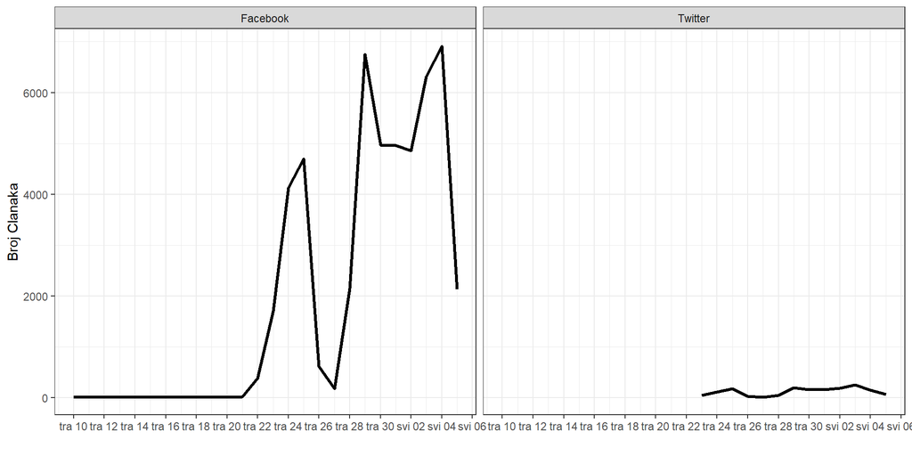

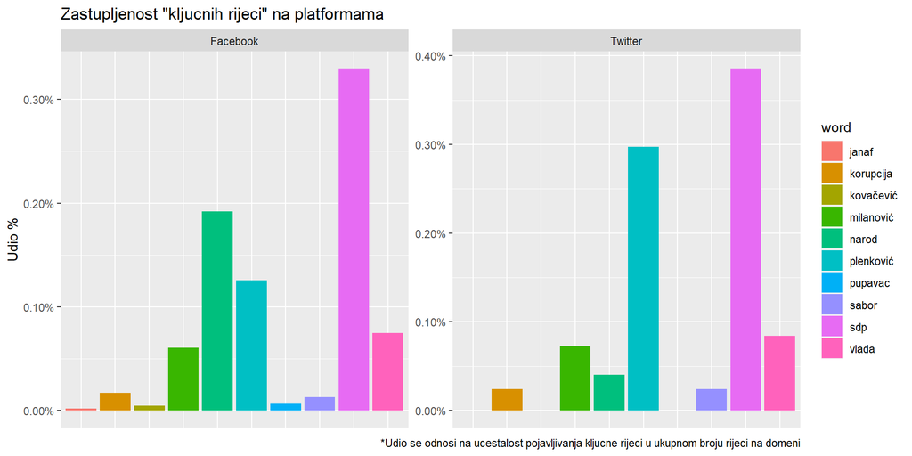

### Oblak riječi

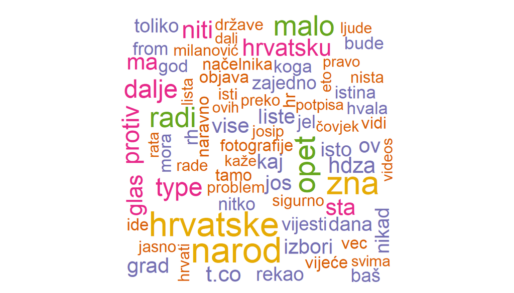

### Sentiment

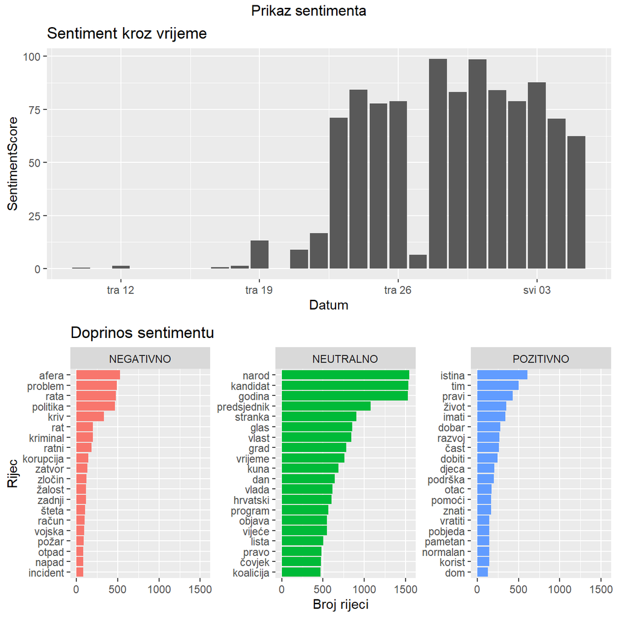

**Razlike i promjene kroz vrijeme**

### Riječi kroz vrijeme

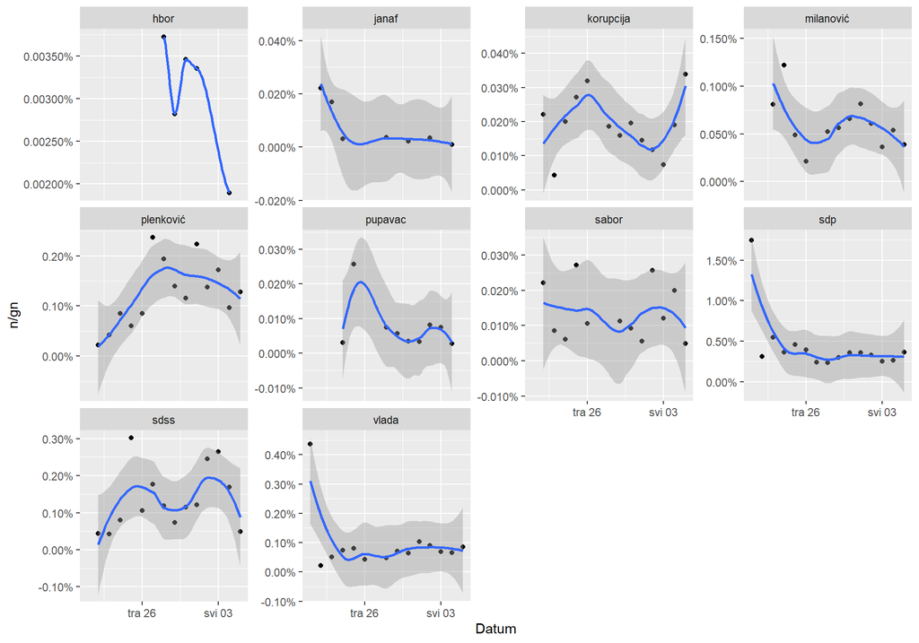